# Crosstech Solutions Group

Лексический анализ публикаций компании на Хабре

Автор

Назаровская Вероника

Дата публикации

19 декабря 2025 г.

## Введение

В данном разделе представлены результаты комплексного анализа текстов статей, включающего аннотирование, частотный анализ, расчёт TF-IDF, анализ распределения слов с помощью диаграммы Ципфа, сентимент-анализ и построение эмбеддингов.

Ну, обо все по порядку)

## Токенизация и лемматизация

Как обычно подгружаю все необходимые пакеты.

```r
library(tidyverse)
library(tidytext)
library(udpipe)
library(stopwords)
library(wordcloud)
library(RColorBrewer)
library(extrafont)
library(widyr)
library(reticulate)
library(slider)
library(irlba)
```

Теперь загружаю широко известную UdPipe-модель SynTagRus для аннотирования текстов самых популярных статей. Это позволит сделать мне выводы о том, какие темы вызывали у аудитории наиболее бурный интерес.

```r
russian_model <- udpipe_load_model(file = "russian-syntagrus-ud-2.5-191206.udpipe")
```

В чанке ниже я аннотирую тексты статей и перевожу результат в тиббл.

```r
ctsg_articles_annotate <- udpipe_annotate(russian_model, result$text, doc_id = result$hit_id)

ctsg_articles_pos <- ctsg_articles_annotate |>
  as_tibble()
```

Получается примерно такая таблица (при визуализации таблицы я убрала столбец **sentence**, чтобы выглядело опрятнее на странице). Полный вариант тиббла можно забрать [здесь](https://github.com/verona238/my-r-project/raw/refs/heads/main/data/ctsg_articles_pos.RData).

| doc_id | paragraph_id | sentence_id | token_id | token | lemma | upos | xpos | feats | head_token_id | dep_rel | deps | misc |
| --- | --- | --- | --- | --- | --- | --- | --- | --- | --- | --- | --- | --- |
| 1 | 1 | 1 | 1 | В | в | ADP | NA | NA | 3 | case | NA | NA |
| 1 | 1 | 1 | 2 | последние | последний | ADJ | NA | Animacy=Inan\|Case=Acc\|Degree=Pos\|Number=Plur | 3 | amod | NA | NA |
| 1 | 1 | 1 | 3 | годы | год | NOUN | NA | Animacy=Inan\|Case=Acc\|Gender=Masc\|Number=Plur | 4 | obl | NA | NA |
| 1 | 1 | 1 | 4 | появляется | появляться | VERB | NA | Aspect=Imp\|Mood=Ind\|Number=Sing\|Person=3\|Tense=Pres\|VerbForm=Fin\|Voice=Mid | 0 | root | NA | NA |
| 1 | 1 | 1 | 5 | всё | все | PART | NA | NA | 6 | advmod | NA | NA |
| 1 | 1 | 1 | 6 | больше | больше | NUM | NA | NA | 7 | nummod | NA | NA |
| 1 | 1 | 1 | 7 | технологий | технология | NOUN | NA | Animacy=Inan\|Case=Gen\|Gender=Fem\|Number=Plur | 4 | nsubj | NA | NA |
| 1 | 1 | 1 | 8 | с | с | ADP | NA | NA | 9 | case | NA | NA |
| 1 | 1 | 1 | 9 | использованием | использование | NOUN | NA | Animacy=Inan\|Case=Ins\|Gender=Neut\|Number=Sing | 7 | nmod | NA | NA |
| 1 | 1 | 1 | 10 | Computer | Computer | PROPN | NA | Foreign=Yes | 9 | flat:foreign | NA | NA |

Создам еще один [тиббл](https://github.com/verona238/my-r-project/raw/refs/heads/main/data/result_words_tidy.RData), в котором будут храниться все токены без стоп-слов.

```r
sw <- stopwords(language = "ru", source = "stopwords-iso")

result_words_tidy <- ctsg_articles_pos  |>
  filter(!lemma %in% sw)
```

| doc_id | paragraph_id | sentence_id | token_id | token | lemma | upos | xpos | feats | head_token_id | dep_rel | deps | misc |
| --- | --- | --- | --- | --- | --- | --- | --- | --- | --- | --- | --- | --- |
| 1 | 1 | 1 | 4 | появляется | появляться | VERB | NA | Aspect=Imp\|Mood=Ind\|Number=Sing\|Person=3\|Tense=Pres\|VerbForm=Fin\|Voice=Mid | 0 | root | NA | NA |
| 1 | 1 | 1 | 7 | технологий | технология | NOUN | NA | Animacy=Inan\|Case=Gen\|Gender=Fem\|Number=Plur | 4 | nsubj | NA | NA |
| 1 | 1 | 1 | 9 | использованием | использование | NOUN | NA | Animacy=Inan\|Case=Ins\|Gender=Neut\|Number=Sing | 7 | nmod | NA | NA |
| 1 | 1 | 1 | 10 | Computer | Computer | PROPN | NA | Foreign=Yes | 9 | flat:foreign | NA | NA |
| 1 | 1 | 1 | 11 | Vision | Vision | PROPN | NA | Foreign=Yes | 9 | flat:foreign | NA | SpaceAfter=No |
| 1 | 1 | 1 | 12 | : | : | PUNCT | NA | NA | 4 | punct | NA | NA |
| 1 | 1 | 1 | 15 | беспилотные | беспилотный | ADJ | NA | Case=Nom\|Degree=Pos\|Number=Plur | 16 | amod | NA | NA |
| 1 | 1 | 1 | 16 | автомобили | автомобиль | NOUN | NA | Animacy=Inan\|Case=Nom\|Gender=Masc\|Number=Plur | 4 | parataxis | NA | SpaceAfter=No |
| 1 | 1 | 1 | 17 | , | , | PUNCT | NA | NA | 19 | punct | NA | NA |
| 1 | 1 | 1 | 19 | Face | Face | PROPN | NA | Foreign=Yes | 16 | conj | NA | NA |

Тут учитываются знаки препинания, но их легко можно будет убрать далее.

Далее я решила построить облако слов из существительных. Мы видим, что наиболее чатыми словами являются, связанные с трудоустройством.

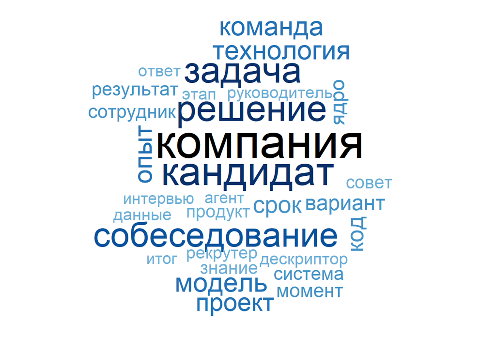

```r
set.seed(123)
nouns <- result_words_tidy  |>
  filter(upos %in% c("NOUN")) |>
  count(lemma) |>
  arrange(-n)

pal <- RColorBrewer::brewer.pal(9, "Blues")[4:10]
wordcloud(nouns$lemma, nouns$n, colors = pal, max.words = 30)
```

Затем я считаю абсолютную частотность слов в самых популярных статьях. Здесь как раз-таки я убираю знаки препинания, которые создали бы некоторый шум.

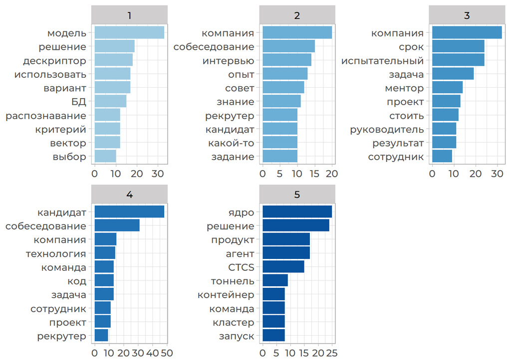

```r
freq_counts <- result_words_tidy |>
  filter(upos != "PUNCT") |>
  count(lemma, doc_id, sort = TRUE) |>
  rename(count = n)

#Абсолютная частотность
freq_counts |>
  group_by(doc_id) |>
  slice_head(n = 10) |>
  ungroup() |>
  ggplot(aes(reorder_within(lemma, count, doc_id), count, fill = as.factor(doc_id))) +
  geom_col(show.legend = F) +
  scale_fill_manual(values = pal) +
  scale_x_reordered() +
  facet_wrap(~doc_id, nrow = 2, scales = "free") +
  coord_flip()  +
  theme_light() +
  theme(text = element_text(size = 12, family = "Montserrat Medium"),
        strip.background = element_rect(fill = "#D0CECE"),
        strip.text = element_text(color = "black")) +
 xlab(NULL) +
  ylab(NULL)
```

Мы видим, что тематически статьи с номерами 2, 3 и 4 будто бы очень близки. Может показаться, что это преждевременные выводы, но забегая вперед скажу, что, действительно, в некоторых статьях всего пула статей выделяется топик об особенностях найма сотрудников в компанию. Неудивительно, потому что эта тема по-прежнему очень актуальна, хоть сейчас и нет такого бума вката в ИТ и рынок труда в целом очень изменился.

Но ограничиваться абсолютной частотностью не нужно. Тем более нужно учитывать, что статьи имеют разную длину (минимальная длина текста популярной статьи содержит 1851 слов, а максимальная — 3348). Поэтому смотрим относительную частотность tf-idf.

```r
tokens_tf <- ctsg_articles_pos |>
  mutate(total = nrow(ctsg_articles_pos)) |>
  add_count(lemma, sort = TRUE) |>
  distinct(doc_id, lemma, total, n) |>
  mutate(tf = n / total) |>
  arrange(tf)
```

Как всегда представляю только небольшой фрагмент тиббла. Полную таблицу можно забрать по [ссылке](https://github.com/verona238/my-r-project/raw/refs/heads/main/data/tokens_tf.RData).

| doc_id | lemma | total | n | tf |
| --- | --- | --- | --- | --- |
| 1 | появляться | 15364 | 1 | 6.508722e-05 |
| 1 | Computer | 15364 | 1 | 6.508722e-05 |
| 1 | Vision | 15364 | 1 | 6.508722e-05 |
| 1 | беспилотный | 15364 | 1 | 6.508722e-05 |
| 1 | автомобиль | 15364 | 1 | 6.508722e-05 |
| 1 | телефон | 15364 | 1 | 6.508722e-05 |
| 1 | камера | 15364 | 1 | 6.508722e-05 |
| 1 | способный | 15364 | 1 | 6.508722e-05 |
| 1 | утечка | 15364 | 1 | 6.508722e-05 |
| 1 | теплоизоляция | 15364 | 1 | 6.508722e-05 |

По полученным данным можно построить гистограмму. Она доказывает распределение слов естественных языков по Закону Ципфа.[^1]

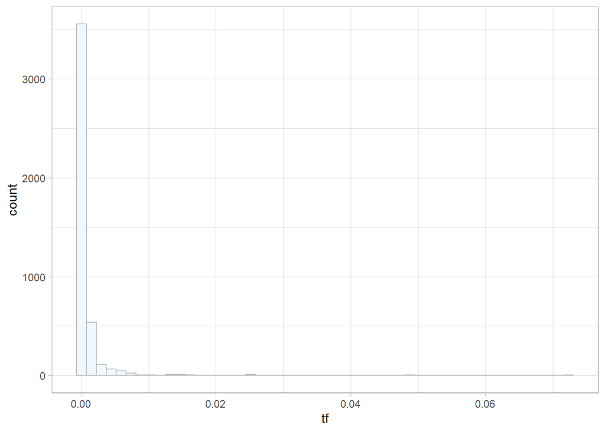

```r
tokens_tf |>
  ggplot(aes(tf)) +
  geom_histogram(show.legend = FALSE,
                 fill = "aliceblue",
                 color = "grey",
                 bins = 50) +
  theme_light()
```

Вношу последние штрихи и визуализирую результат.

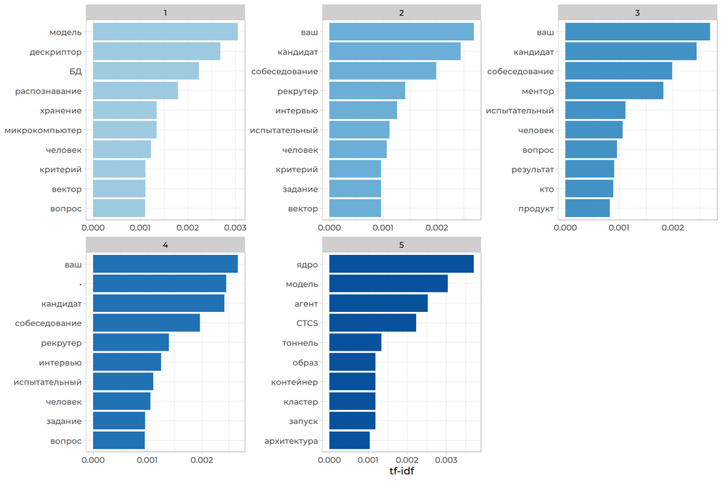

```r
ctsg_tfidf <- tokens_tf |>
  bind_tf_idf(lemma, doc_id, n)

#наиболее характерные для документов токены
ctsg_tfidf |>
  arrange(-tf_idf) |>
  group_by(doc_id) |>
  slice_head(n = 10) |>
  ungroup() |>
  ggplot(aes(reorder_within(lemma, tf_idf, doc_id), tf_idf, fill = as.factor(doc_id))) +
  geom_col(show.legend = F) +
  labs(x = NULL, y = "tf-idf") +
  facet_wrap(~doc_id, scales = "free", nrow = 2) +
  scale_x_reordered() +
  scale_fill_manual(values = pal) +
  coord_flip() +
  theme_light() +
  theme(text = element_text(size = 12, family = "Montserrat Medium"),
        strip.background = element_rect(fill = "#D0CECE"),
        strip.text = element_text(color = "black"))
```

Да, здесь мы видим немного другие слова, однако они семантически очень близки с теми, что показал нам анализ абсолютных частот. Так, мы можем сделать вывод о том, что среди популярных статей мы можем выделить 2 кластера статей:

- кластер статей о трудоустройстве и софт-скиллах в целом;
- кластер технических статей, в которых описываются технологии (причем применяемые/разрабатываемые компанией).

Причем в статье №1 можно сделать вывод о том, что речь идет о машинном обучении для задачи распознавания, а статья №5 описывает контейнерные технологии. Неудивительно, что статьи с такой тематикой вошли в ТОП статей компании. Машинное обучение по-прежнему является востребованным топиком в технарском кругу. Контейнерные технологии также не сбавляет свои обороты в популярности среди технарей.[^2]

Вот так небольшой анализ частот позволил сделать выводы о содержании статей. Затем это можно расширить и применить для всего пула статей.

## Сентимент-анализ

В этом подразделе я рассмотрю анализ эмоционального окраса статей компании на Хабре. Мне кажется, это интересная тема, потому что (по моему сложившемуся мнению) в основном сентимент-анализ применяют для художественной литературы.

Интересно будет узнать, пишут ли технари сухим безэмоциональным языком, или же в некоторых текстах прослеживаются положительные или отрицательные коннотации. Давайте узнаем и потом проанализируем полученные результаты :)

Для начала подготовлю Python-окружение для работы с моделью BERT.

```r
use_python("C:/Users/nazarovskaya.v/AppData/Local/Programs/Python/Python313")
py_config()
py_eval("1+1")
py_module_available("transformers")
py_module_available("torch")
transformers <- import("transformers")

sentiment_pipeline <- transformers$pipeline(
  "sentiment-analysis",
  model="seara/rubert-tiny2-russian-sentiment"
)
```

Затем применю пайплайн для анализа текстов. Здесь я заменила параметр **max_length**, чтобы он адекватно мог анализировать предложенные статьи.

```r
articles_tbl <- tibble(text = articles_ctsg_full$text)

results_SA <- sentiment_pipeline(
  as.list(articles_tbl$text),
  truncation = TRUE,
  max_length = as.integer(512)
)

results_tbl <- tibble(
  label = map_chr(results_SA, function(x) x$label),
  score = map_dbl(results_SA, function(x) x$score)
)

results_tbl <- results_tbl |>
  mutate(id = row_number()) |>
  mutate(id = as.integer(id)) |>
  inner_join(articles_ctsg_full, by = "id") |>
  select(id, title, label, score)
```

И визуализирую полученную таблицу.

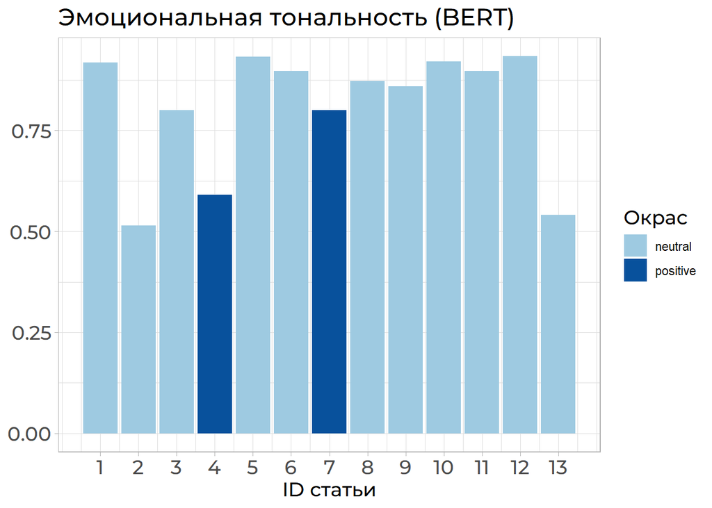

```r
results_tbl |>
  mutate(index = row_number()) |>
  mutate(score = case_when(label == "negative" ~ score * -1,
                           .default = score)) |>
  ggplot(aes(index, score, fill = label)) +
  geom_col(show.legend = T) +
  scale_x_continuous(breaks = seq(1, 13, 1)) +
  labs(title = "Эмоциональная тональность (BERT)",
       x = "ID статьи",
       y = NULL) +
  theme_light() +
  theme(axis.title = element_text(size = 14, family = "Montserrat Medium"),
        title = element_text(size = 14, family = "Montserrat Medium"),
        axis.text = element_text(size = 14, family = "Montserrat Medium")) +
  scale_fill_manual(name = "Окрас", values = c(pal[1], pal[5]))
```

Результаты показали, что по мнению BERT среди статей компаний есть две, которые имеют положительный окрас. Оказалось, что это 2 следующие статьи:

| id | title | text | length | link | complexity_label | date | year | month | wday | hour | time | read_time_min | reach_value | unique_readers | votes | mark | num_of_comments | tags | hubs |
| --- | --- | --- | --- | --- | --- | --- | --- | --- | --- | --- | --- | --- | --- | --- | --- | --- | --- | --- | --- |
| 4 | От идеи до первого выпуска: как и зачем мы запустили подкаст про ИБ? | Привет! Это Яна Ильина, HRBP CrossTech Solutions Group, … | 1172 | https://habr.com/ru/... | NA | 2025-02-13 | 2025 | Feb | Thu | 14 | 14H 29M 0S | 6 | 703 | 703 | 6 | 9 | 2 | подкаст, бренд, выпуски, … | Блог компании Crosstech … |
| 7 | Как организовать внутренний митап, чтобы он зашел команде? Наши принципы и немного истории | Всем привет! Меня зовут Ульяна Петракова, я специалист … | 367 | https://habr.com/ru/... | NA | 2024-07-25 | 2024 | Jul | Thu | 16 | 16H 8M 0S | 2 | 743 | 743 | 4 | 8 | 1 | it-компании, карьера в … | Блог компании Crosstech … |

Итак, оставляю ссылки на эти статьи:

- От идеи до первого выпуска: как и зачем мы запустили подкаст про ИБ?[^3]
- Как организовать внутренний митап, чтобы он зашел команде? Наши принципы и немного истории[^4].

Обе эти статьи затрагивают HR-бренд, где ОЧЕНЬ важен позитивный окрас текста. Поэтому я думаю, BERT здесь не ошибся.

## Эмбеддинги

Ну и последнее, что я рассмотрю в этом проекте, это векторное представление слов. Ну чтош, приступим!

Сейчас я аннотирую тексты всех статей компании.

```r
ctsg_articles_annotate_all <- udpipe_annotate(russian_model, articles_ctsg_full$text, doc_id = articles_ctsg_full$id)

ctsg_articles_pos_all <- ctsg_articles_annotate_all |>
  as_tibble()
```

Делаю контекстные окна.

```r
slide_windows <- function(tbl, window_size) {
 skipgrams <- slider::slide(
   tbl,
    ~.x,
    .after = window_size - 1,
    .step = 1,
    .complete = TRUE
  )

  safe_mutate <- safely(mutate)

  out <- map2(skipgrams,
              1:length(skipgrams),
              ~ safe_mutate(.x, window_id = .y))

  out  |>
    transpose()  |>
    pluck("result")  |>
    compact()  |>
    bind_rows()
}
```

Затем убираю ненужное и применяю функцию. Затем здесь же высчитываю PMI и PPMI.

```r
sw <- stopwords(language = "ru", source = "stopwords-iso")

articles_tokens_pruned <- ctsg_articles_pos_all  |>
  filter(
    !lemma %in% sw,
    !upos %in% c("NUM", "SYM", "X", "PUNCT"),
    str_detect(lemma, "^[\\p{L}-]+$")
  ) |>
  select(doc_id, lemma)

nested_articles <- articles_tokens_pruned |>
  nest(lemma = c(lemma))

articles_windows <- nested_articles |>
  mutate(lemma = map(lemma, slide_windows, 4L))  |>
  unnest(lemma) |>
  unite(window_id, doc_id, window_id)

articles_pmi  <- articles_windows  |>
  pairwise_pmi(lemma, window_id)

articles_ppmi <- articles_pmi |>
  mutate(ppmi = case_when(pmi < 0 ~ 0,
                          .default = pmi))
```

Давайте посмотрим на полученную таблицу. Для preview я взяла 10 последних строк (через tail). Мне нравится, как получилось! Полную таблицу как всегда предлагаю забрать по [ссылке](https://github.com/verona238/my-r-project/raw/refs/heads/main/data/articles_ppmi.RData).

| item1 | item2 | pmi | ppmi |
| --- | --- | --- | --- |
| смолл-толка | часовой | 6.640088 | 6.640088 |
| небольшой | смолл-толка | 5.030650 | 5.030650 |
| руководитель | смолл-толка | 3.713349 | 3.713349 |
| подобный | смолл-толка | 5.136011 | 5.136011 |
| поведение | смолл-толка | 5.541476 | 5.541476 |
| беседа | смолл-толка | 6.234623 | 6.234623 |
| часовой | смолл-толка | 6.640088 | 6.640088 |
| отправлять | почта | 6.468238 | 6.468238 |
| срок | почта | 4.560647 | 4.560647 |
| отклик | почта | 7.620918 | 7.620918 |

Теперь визуализирую полученные результаты.

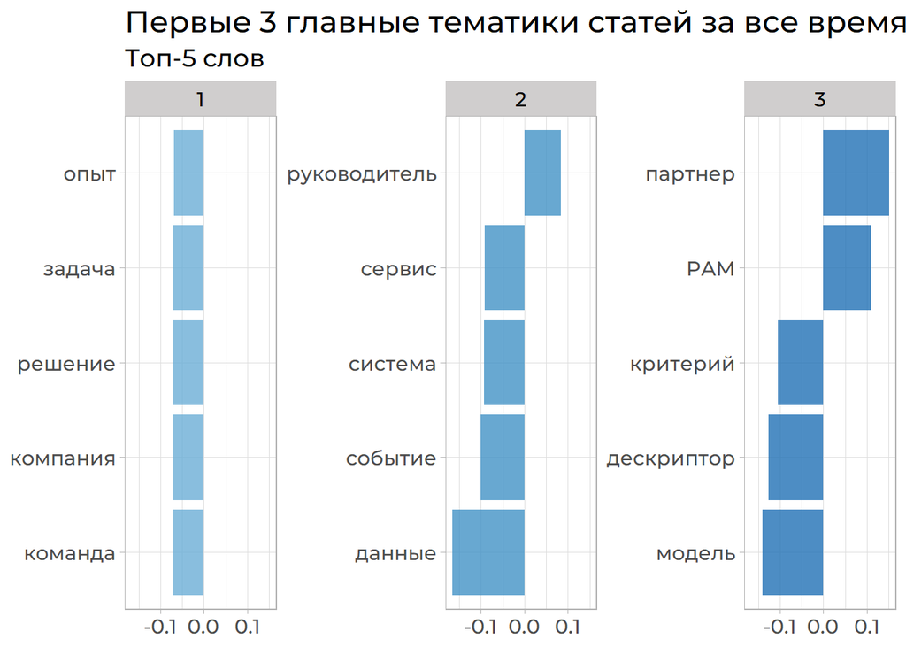

```r
set.seed(123)
word_emb <- articles_ppmi |>
  widely_svd(item1, item2, ppmi,
             weight_d = FALSE, nv = 100)

pal2 <- RColorBrewer::brewer.pal(9, "Blues")[5:9]

word_emb |>
  filter(dimension < 4) |>
  mutate(dimension = factor(dimension)) |>
  group_by(dimension) |>
  top_n(5, abs(value)) |>
  ungroup() |>
  ggplot(aes(reorder_within(item1, value, dimension), value, fill = dimension)) +
  geom_col(alpha = 0.8, show.legend = FALSE) +
  facet_wrap(~dimension, scales = "free_y", ncol = 3) +
  scale_x_reordered() +
  scale_fill_manual(values = pal2) +
  coord_flip() +
  labs(
    x = NULL,
    y = NULL,
    title = "Первые 3 главные тематики статей за все время",
    subtitle = "Топ-5 слов"
  ) +
  theme_light() +
  theme(text = element_text(size = 14, family = "Montserrat Medium"),
        strip.background = element_rect(fill = "#D0CECE"),
        strip.text = element_text(color = "black"))
```

С другой стороны, я понимаю, что на 13 статьях не построишь адекватно топики, потому что данных слишком мало. Именно поэтому я так и не решилась на проведение тематического моделирования этого пула статей.

Можно будет масштабировать исследования и применить его не только к статьям компании, а к статьям на Хабре за 2025 год! Было бы интересно посмотреть, что так получится)

Спасибо большое, что дочитали до конца! И прошу прощения за возможные очепятки. Буду очень рада обратной связи)

## Литература

1. Закон Ципфа // https://ru.wikipedia.org/wiki/%D0%97%D0%B0%D0%BA%D0%BE%D0%BD_%D0%A6%D0%B8%D0%BF%D1%84%D0%B0

2. AI & ML Trends in Cloud-Native Infrastructure // https://blogs.vultr.com/Cloud-Native-AI-and-Machine-Learning

3. От идеи до первого выпуска: как и зачем мы запустили подкаст про ИБ? // https://habr.com/ru/companies/ctsg/articles/882176/

4. Как организовать внутренний митап, чтобы он зашел команде? Наши принципы и немного истории // https://habr.com/ru/companies/ctsg/articles/831464/

## Сноски

[^1]: Закон Ципфа
[^2]: AI & ML Trends in Cloud-Native Infrastructure
[^3]: От идеи до первого выпуска: как и зачем мы запустили подкаст про ИБ?
[^4]: Как организовать внутренний митап, чтобы он зашел команде? Наши принципы и немного истории